# Wrangle Act

- Gather
  - Twitter archive
  - Image_predictions
  - Twitter_JSON
- Assess
- Clean
- Reassessment for analysis
- Analysis and visualization

### Gather

```python
import pandas as pd
import numpy as np
import requests
import os
import glob
import json
from bs4 import BeautifulSoup
```

#### 1.Twitter_archive

```python
archive = pd.read_csv('/Users/seattlehibiscus/Desktop/learning/数据分析项目/p2/project/twitter-archive-enhanced.csv')
```

```python
archive.head()
```

|  | tweet_id | in_reply_to_status_id | in_reply_to_user_id | timestamp | source | text | retweeted_status_id | retweeted_status_user_id | retweeted_status_timestamp | expanded_urls | rating_numerator | rating_denominator | name | doggo | floofer | pupper | puppo |
| --- | --- | --- | --- | --- | --- | --- | --- | --- | --- | --- | --- | --- | --- | --- | --- | --- | --- |
| 0 | 892420643555336193 | NaN | NaN | 2017-08-01 16:23:56 +0000 | <a href="http://twitter.com/download/iphone" r... | This is Phineas. He's a mystical boy. Only eve... | NaN | NaN | NaN | https://twitter.com/dog_rates/status/892420643... | 13 | 10 | Phineas | None | None | None | None |
| 1 | 892177421306343426 | NaN | NaN | 2017-08-01 00:17:27 +0000 | <a href="http://twitter.com/download/iphone" r... | This is Tilly. She's just checking pup on you.... | NaN | NaN | NaN | https://twitter.com/dog_rates/status/892177421... | 13 | 10 | Tilly | None | None | None | None |
| 2 | 891815181378084864 | NaN | NaN | 2017-07-31 00:18:03 +0000 | <a href="http://twitter.com/download/iphone" r... | This is Archie. He is a rare Norwegian Pouncin... | NaN | NaN | NaN | https://twitter.com/dog_rates/status/891815181... | 12 | 10 | Archie | None | None | None | None |
| 3 | 891689557279858688 | NaN | NaN | 2017-07-30 15:58:51 +0000 | <a href="http://twitter.com/download/iphone" r... | This is Darla. She commenced a snooze mid meal... | NaN | NaN | NaN | https://twitter.com/dog_rates/status/891689557... | 13 | 10 | Darla | None | None | None | None |
| 4 | 891327558926688256 | NaN | NaN | 2017-07-29 16:00:24 +0000 | <a href="http://twitter.com/download/iphone" r... | This is Franklin. He would like you to stop ca... | NaN | NaN | NaN | https://twitter.com/dog_rates/status/891327558... | 12 | 10 | Franklin | None | None | None | None |

#### 2.Image_predictions

```python
url = 'https://d17h27t6h515a5.cloudfront.net/topher/2017/August/599fd2ad_image-predictions/image-predictions.tsv'
prediction = requests.get(url)
prediction
```

```
<Response [200]>
```

```python
curdir = os.getcwd()
```

```python
with open(os.path.join(curdir, 'predictions'), mode='wb') as file:
    file.write(prediction.content)
```

```python
predictions = pd.read_csv(os.path.join(curdir, 'predictions'), sep='\t')
predictions.head()
```

|  | tweet_id | jpg_url | img_num | p1 | p1_conf | p1_dog | p2 | p2_conf | p2_dog | p3 | p3_conf | p3_dog |
| --- | --- | --- | --- | --- | --- | --- | --- | --- | --- | --- | --- | --- |
| 0 | 666020888022790149 | https://pbs.twimg.com/media/CT4udn0WwAA0aMy.jpg | 1 | Welsh_springer_spaniel | 0.465074 | True | collie | 0.156665 | True | Shetland_sheepdog | 0.061428 | True |
| 1 | 666029285002620928 | https://pbs.twimg.com/media/CT42GRgUYAA5iDo.jpg | 1 | redbone | 0.506826 | True | miniature_pinscher | 0.074192 | True | Rhodesian_ridgeback | 0.072010 | True |
| 2 | 666033412701032449 | https://pbs.twimg.com/media/CT4521TWwAEvMyu.jpg | 1 | German_shepherd | 0.596461 | True | malinois | 0.138584 | True | bloodhound | 0.116197 | True |
| 3 | 666044226329800704 | https://pbs.twimg.com/media/CT5Dr8HUEAA-lEu.jpg | 1 | Rhodesian_ridgeback | 0.408143 | True | redbone | 0.360687 | True | miniature_pinscher | 0.222752 | True |
| 4 | 666049248165822465 | https://pbs.twimg.com/media/CT5IQmsXIAAKY4A.jpg | 1 | miniature_pinscher | 0.560311 | True | Rottweiler | 0.243682 | True | Doberman | 0.154629 | True |

#### 3.Twitter_JSON

```python
url = 'https://s3.amazonaws.com/video.udacity-data.com/topher/2018/November/5be5fb7d_tweet-json/tweet-json.txt'
JSON = requests.get(url)
JSON
```

```
<Response [200]>
```

```python
with open(os.path.join(curdir, 'JSON.txt'), mode = 'wb') as file:
    file.write(JSON.content)
```

```python
data = []
with open('/Users/seattlehibiscus/Desktop/learning/数据分析项目/p2/project/JSON.txt') as JSON_file:
    for line in JSON_file:
        data.append(json.loads(line))
```

```python
data[0]
```

[output not shown]

[output cut: 45 more lines]

```
  'follow_request_sent': False,
  'notifications': False,
  'translator_type': 'none'},
 'geo': None,
 'coordinates': None,
 'place': None,
 'contributors': None,
 'is_quote_status': False,
 'retweet_count': 8853,
 'favorite_count': 39467,
 'favorited': False,
 'retweeted': False,
 'possibly_sensitive': False,
 'possibly_sensitive_appealable': False,
 'lang': 'en'}
```

```python
ID = pd.Series([element['id'] for element in data], name='ID')
retweet_count = pd.Series([element['retweet_count'] for element in data], name='retweet_count')
favorite_count = pd.Series([element['favorite_count'] for element in data], name='favorite_count')
```

```python
twitter_json = pd.concat([ID, retweet_count, favorite_count], axis=1)
twitter_json.head()
```

|  | ID | retweet_count | favorite_count |
| --- | --- | --- | --- |
| 0 | 892420643555336193 | 8853 | 39467 |
| 1 | 892177421306343426 | 6514 | 33819 |
| 2 | 891815181378084864 | 4328 | 25461 |
| 3 | 891689557279858688 | 8964 | 42908 |
| 4 | 891327558926688256 | 9774 | 41048 |

```python
twitter_json = twitter_json.rename(columns={'ID': 'tweet_id'})
twitter_json.head()
```

|  | tweet_id | retweet_count | favorite_count |
| --- | --- | --- | --- |
| 0 | 892420643555336193 | 8853 | 39467 |
| 1 | 892177421306343426 | 6514 | 33819 |
| 2 | 891815181378084864 | 4328 | 25461 |
| 3 | 891689557279858688 | 8964 | 42908 |
| 4 | 891327558926688256 | 9774 | 41048 |

### Assess

#### archive

```python
archive.info()
```

```
<class 'pandas.core.frame.DataFrame'>
RangeIndex: 2356 entries, 0 to 2355
Data columns (total 17 columns):
tweet_id                      2356 non-null int64
in_reply_to_status_id         78 non-null float64
in_reply_to_user_id           78 non-null float64
timestamp                     2356 non-null object
source                        2356 non-null object
text                          2356 non-null object
retweeted_status_id           181 non-null float64
retweeted_status_user_id      181 non-null float64
retweeted_status_timestamp    181 non-null object
expanded_urls                 2297 non-null object
rating_numerator              2356 non-null int64
rating_denominator            2356 non-null int64
name                          2356 non-null object
doggo                         2356 non-null object
floofer                       2356 non-null object
pupper                        2356 non-null object
puppo                         2356 non-null object
dtypes: float64(4), int64(3), object(10)
memory usage: 313.0+ KB
```

```python
archive.sample(5)
```

|  | tweet_id | in_reply_to_status_id | in_reply_to_user_id | timestamp | source | text | retweeted_status_id | retweeted_status_user_id | retweeted_status_timestamp | expanded_urls | rating_numerator | rating_denominator | name | doggo | floofer | pupper | puppo |
| --- | --- | --- | --- | --- | --- | --- | --- | --- | --- | --- | --- | --- | --- | --- | --- | --- | --- |
| 1031 | 745422732645535745 | NaN | NaN | 2016-06-22 01:06:43 +0000 | <a href="http://twitter.com/download/iphone" r... | We only rate dogs. Pls stop sending in non-can... | NaN | NaN | NaN | https://twitter.com/dog_rates/status/745422732... | 9 | 10 | very | None | None | None | None |
| 861 | 763103485927849985 | NaN | NaN | 2016-08-09 20:03:43 +0000 | <a href="http://twitter.com/download/iphone" r... | This is Belle. She's a Butterflop Hufflepoof. ... | NaN | NaN | NaN | https://twitter.com/dog_rates/status/763103485... | 10 | 10 | Belle | None | None | None | None |
| 307 | 835685285446955009 | NaN | NaN | 2017-02-26 02:57:52 +0000 | <a href="http://twitter.com/download/iphone" r... | RT @dog_rates: This is Rory. He's got an inter... | 7.869631e+17 | 4.196984e+09 | 2016-10-14 16:13:10 +0000 | https://twitter.com/dog_rates/status/786963064... | 12 | 10 | Rory | None | None | None | None |
| 1123 | 730427201120833536 | NaN | NaN | 2016-05-11 15:59:50 +0000 | <a href="http://twitter.com/download/iphone" r... | This is Crystal. She's flawless. Really wants ... | NaN | NaN | NaN | https://twitter.com/dog_rates/status/730427201... | 11 | 10 | Crystal | None | None | None | None |
| 2146 | 669923323644657664 | NaN | NaN | 2015-11-26 16:59:01 +0000 | <a href="http://twitter.com/download/iphone" r... | This is a spotted Lipitor Rumpelstiltskin name... | NaN | NaN | NaN | https://twitter.com/dog_rates/status/669923323... | 10 | 10 | a | None | None | None | None |

```python
all_none = archive.loc[(archive.doggo=='None') & (archive.floofer=='None') & (archive.pupper=='None') & (archive.puppo=='None'), :]
len(all_none)
```

```
1976
```

```python
archive.rating_denominator.value_counts()
```

```
10     2333
11        3
50        3
80        2
20        2
2         1
16        1
40        1
70        1
15        1
90        1
110       1
120       1
130       1
150       1
170       1
7         1
0         1
Name: rating_denominator, dtype: int64
```

```python
archive[archive.rating_denominator==170]
```

|  | tweet_id | in_reply_to_status_id | in_reply_to_user_id | timestamp | source | text | retweeted_status_id | retweeted_status_user_id | retweeted_status_timestamp | expanded_urls | rating_numerator | rating_denominator | name | doggo | floofer | pupper | puppo |
| --- | --- | --- | --- | --- | --- | --- | --- | --- | --- | --- | --- | --- | --- | --- | --- | --- | --- |
| 1120 | 731156023742988288 | NaN | NaN | 2016-05-13 16:15:54 +0000 | <a href="http://twitter.com/download/iphone" r... | Say hello to this unbelievably well behaved sq... | NaN | NaN | NaN | https://twitter.com/dog_rates/status/731156023... | 204 | 170 | this | None | None | None | None |

```python
pd.Series(archive.name.unique()).sort_values()
```

```
482            Abby
459             Ace
813            Acro
616           Adele
814           Aiden
57              Aja
273           Akumi
410              Al
437          Albert
95            Albus
519         Aldrick
854       Alejandro
219       Alexander
558    Alexanderson
276             Alf
```

[output cut: 47 more lines]

```python
# collect those lower-case names
name = pd.Series(archive.name.unique())
name_lower = []
for element in name:
    if str(element)[0].islower():
        name_lower.append(element)
name_lower
```

```
['such',
 'a',
 'quite',
 'not',
 'one',
 'incredibly',
 'mad',
 'an',
 'very',
 'just',
 'my',
 'his',
 'actually',
 'getting',
 'this',
 'unacceptable',
 'all',
 'old',
 'infuriating',
 'the',
 'by',
 'officially',
 'life',
 'light',
 'space']
```

```python
archive.rating_numerator.value_counts()
```

```
12      558
11      464
10      461
13      351
9       158
8       102
7        55
14       54
5        37
6        32
3        19
4        17
1         9
2         9
420       2
```

[output cut: 26 more lines]

```python
len(archive[archive.name=='None'])
```

```
745
```

```python
archive.text[0]
```

```
"This is Phineas. He's a mystical boy. Only ever appears in the hole of a donut. 13/10 https://t.co/MgUWQ76dJU"
```

```python
archive.expanded_urls[0]
```

```
'https://twitter.com/dog_rates/status/892420643555336193/photo/1'
```

```python
archive.timestamp.sort_values
```

```
<bound method Series.sort_values of 0       2017-08-01 16:23:56 +0000
1       2017-08-01 00:17:27 +0000
2       2017-07-31 00:18:03 +0000
3       2017-07-30 15:58:51 +0000
4       2017-07-29 16:00:24 +0000
5       2017-07-29 00:08:17 +0000
6       2017-07-28 16:27:12 +0000
7       2017-07-28 00:22:40 +0000
8       2017-07-27 16:25:51 +0000
9       2017-07-26 15:59:51 +0000
10      2017-07-26 00:31:25 +0000
11      2017-07-25 16:11:53 +0000
12      2017-07-25 01:55:32 +0000
13      2017-07-25 00:10:02 +0000
14      2017-07-24 17:02:04 +0000
```

[output cut: 47 more lines]

```python
archive[archive.tweet_id.duplicated()]
```

|  | tweet_id | in_reply_to_status_id | in_reply_to_user_id | timestamp | source | text | retweeted_status_id | retweeted_status_user_id | retweeted_status_timestamp | expanded_urls | rating_numerator | rating_denominator | name | doggo | floofer | pupper | puppo |
| --- | --- | --- | --- | --- | --- | --- | --- | --- | --- | --- | --- | --- | --- | --- | --- | --- | --- |

```python
archive.text[302]
```

```
'RT @SchafeBacon2016: @dog_rates Slightly disturbed by the outright profanity, but confident doggos were involved. 11/10, would tailgate aga…'
```

#### predictions

```python
predictions.info()
```

```
<class 'pandas.core.frame.DataFrame'>
RangeIndex: 2075 entries, 0 to 2074
Data columns (total 12 columns):
tweet_id    2075 non-null int64
jpg_url     2075 non-null object
img_num     2075 non-null int64
p1          2075 non-null object
p1_conf     2075 non-null float64
p1_dog      2075 non-null bool
p2          2075 non-null object
p2_conf     2075 non-null float64
p2_dog      2075 non-null bool
p3          2075 non-null object
p3_conf     2075 non-null float64
p3_dog      2075 non-null bool
dtypes: bool(3), float64(3), int64(2), object(4)
memory usage: 152.1+ KB
```

```python
predictions.sample(5)
```

|  | tweet_id | jpg_url | img_num | p1 | p1_conf | p1_dog | p2 | p2_conf | p2_dog | p3 | p3_conf | p3_dog |
| --- | --- | --- | --- | --- | --- | --- | --- | --- | --- | --- | --- | --- |
| 1986 | 872486979161796608 | https://pbs.twimg.com/media/DBuyRlTUwAAYhG9.jpg | 1 | Pembroke | 0.931861 | True | Cardigan | 0.037721 | True | Chihuahua | 0.011967 | True |
| 389 | 673359818736984064 | https://pbs.twimg.com/media/CVhBLohWEAAXtYl.jpg | 1 | English_setter | 0.696568 | True | Brittany_spaniel | 0.104046 | True | Ibizan_hound | 0.034832 | True |
| 837 | 694329668942569472 | https://pbs.twimg.com/media/CaLBJmOWYAQt44t.jpg | 1 | boxer | 0.990060 | True | bull_mastiff | 0.007436 | True | Saint_Bernard | 0.001617 | True |
| 498 | 675820929667219457 | https://pbs.twimg.com/media/CWD_jQMWEAAdYwH.jpg | 1 | basset | 0.556373 | True | beagle | 0.201675 | True | bloodhound | 0.110848 | True |
| 1561 | 793286476301799424 | https://pbs.twimg.com/media/CwJR1okWIAA6XMp.jpg | 1 | Afghan_hound | 0.274637 | True | borzoi | 0.142204 | True | doormat | 0.109677 | False |

```python
predictions.p1_conf.sort_values(ascending=False)
```

```
106     1.000000
1299    0.999984
1229    0.999962
149     0.999956
1372    0.999953
230     0.999945
242     0.999924
1447    0.999916
45      0.999888
865     0.999885
475     0.999876
594     0.999846
1014    0.999837
331     0.999834
1725    0.999833
```

[output cut: 47 more lines]

```python
predictions.loc[predictions.p2_conf <= predictions.p3_conf, :]
```

|  | tweet_id | jpg_url | img_num | p1 | p1_conf | p1_dog | p2 | p2_conf | p2_dog | p3 | p3_conf | p3_dog |
| --- | --- | --- | --- | --- | --- | --- | --- | --- | --- | --- | --- | --- |

```python
predictions.iloc[106,:]
```

```
tweet_id                                 667866724293877760
jpg_url     https://pbs.twimg.com/media/CUS9PlUWwAANeAD.jpg
img_num                                                   1
p1                                            jigsaw_puzzle
p1_conf                                                   1
p1_dog                                                False
p2                                               prayer_rug
p2_conf                                          1.0113e-08
p2_dog                                                False
p3                                                  doormat
p3_conf                                         1.74017e-10
p3_dog                                                False
Name: 106, dtype: object
```

```python
predictions.p1.value_counts()
```

```
golden_retriever             150
Labrador_retriever           100
Pembroke                      89
Chihuahua                     83
pug                           57
chow                          44
Samoyed                       43
toy_poodle                    39
Pomeranian                    38
malamute                      30
cocker_spaniel                30
French_bulldog                26
Chesapeake_Bay_retriever      23
miniature_pinscher            23
seat_belt                     22
Staffordshire_bullterrier     20
German_shepherd               20
Siberian_husky                20
web_site                      19
Cardigan                      19
Shetland_sheepdog             18
teddy                         18
Maltese_dog                   18
beagle                        18
Eskimo_dog                    18
Rottweiler                    17
Shih-Tzu                      17
Lakeland_terrier              17
kuvasz                        16
Italian_greyhound             16
                            ...
grille                         1
pitcher                        1
basketball                     1
three-toed_sloth               1
hummingbird                    1
sundial                        1
pole                           1
sliding_door                   1
Egyptian_cat                   1
syringe                        1
pool_table                     1
harp                           1
piggy_bank                     1
four-poster                    1
walking_stick                  1
remote_control                 1
loupe                          1
bib                            1
cheeseburger                   1
bison                          1
cup                            1
water_bottle                   1
leopard                        1
soccer_ball                    1
cliff                          1
nail                           1
envelope                       1
guenon                         1
bow                            1
fiddler_crab                   1
Name: p1, Length: 378, dtype: int64
```

```python
predictions.img_num.value_counts()
```

```
1    1780
2     198
3      66
4      31
Name: img_num, dtype: int64
```

```python
predictions[predictions.tweet_id.duplicated()]
```

|  | tweet_id | jpg_url | img_num | p1 | p1_conf | p1_dog | p2 | p2_conf | p2_dog | p3 | p3_conf | p3_dog |
| --- | --- | --- | --- | --- | --- | --- | --- | --- | --- | --- | --- | --- |

#### twitter_json

```python
twitter_json.info()
```

```
<class 'pandas.core.frame.DataFrame'>
RangeIndex: 2354 entries, 0 to 2353
Data columns (total 3 columns):
tweet_id          2354 non-null int64
retweet_count     2354 non-null int64
favorite_count    2354 non-null int64
dtypes: int64(3)
memory usage: 55.2 KB
```

```python
twitter_json.sample(5)
```

|  | tweet_id | retweet_count | favorite_count |
| --- | --- | --- | --- |
| 840 | 766793450729734144 | 1565 | 5650 |
| 776 | 776088319444877312 | 179 | 2045 |
| 76 | 877736472329191424 | 17300 | 71144 |
| 1368 | 702321140488925184 | 1156 | 3604 |
| 215 | 850753642995093505 | 10352 | 33348 |

```python
len(twitter_json[twitter_json.tweet_id.duplicated()])
```

```
0
```

```python
twitter_json.favorite_count.value_counts()
```

```
0        179
610        3
345        3
2918       3
1691       3
2176       3
2768       3
1339       3
2706       3
522        2
3134       2
1618       2
250        2
2250       2
2660       2
```

[output cut: 47 more lines]

#### Quality

**archive**

- lowercase name(the lowercase names are not real names)
- wrong data type(tweet_id)
- outliners in columns of rating_numerator and rating_denominator
- E-notation in columns of in_reply_to_status_id & in_reply_to_user_id & retweeted_status_id & retweeted_status_user_id
- missing data(dog types & name & expanded_urls) cannot be wrangled

**predictions**

- wrong data type(tweet_id, img_num)
- lowercase dog category(p1, p2, p3)

**twitter_json**

- wrong data type(tweet_id)
- 'favorite_count' contains 0 which is abnormal

#### Tidiness

##### archive

- dog type(doggo floofer pupper puppo)takes four columns(Each variable forms a column.)
- combine the three data sets

### Clean

```python
archive_clean = archive.copy()
predictions_clean = predictions.copy()
twitter_json_clean = twitter_json.copy()
```

##### Define

*convert four columns of dog type into one column(doggo floofer pupper puppo)*

##### Code

```python
# combine the four columns
archive_clean['type'] = archive_clean.doggo + archive_clean.floofer + archive_clean.pupper + archive_clean.puppo
```

```python
# remove string 'None'
archive_clean.type = archive_clean.type.map(lambda x: x.replace('None', ''))
```

```python
archive_clean.type.value_counts()
```

```
                1976
pupper           245
doggo             83
puppo             29
doggopupper       12
floofer            9
doggopuppo         1
doggofloofer       1
Name: type, dtype: int64
```

```python
# some of them have two labels with an additional 'doggo', therefor remove the subset of 'doggo' from them.
sta = archive_clean[archive_clean.type.str.contains('doggo\w+', regex=True)]
sta.type = sta.type.str.replace('doggo', '')
```

```python
archive_clean.loc[sta.index, 'type'] = sta.loc[sta.index, 'type']
```

```python
archive_clean = archive_clean.drop(['doggo', 'pupper', 'puppo', 'floofer'], axis=1)
```

##### Test

```python
# check columns
archive_clean.sample(5)
```

|  | tweet_id | in_reply_to_status_id | in_reply_to_user_id | timestamp | source | text | retweeted_status_id | retweeted_status_user_id | retweeted_status_timestamp | expanded_urls | rating_numerator | rating_denominator | name | type |
| --- | --- | --- | --- | --- | --- | --- | --- | --- | --- | --- | --- | --- | --- | --- |
| 71 | 878776093423087618 | NaN | NaN | 2017-06-25 00:45:22 +0000 | <a href="http://twitter.com/download/iphone" r... | This is Snoopy. He's a proud #PrideMonthPuppo.... | NaN | NaN | NaN | https://twitter.com/dog_rates/status/878776093... | 13 | 10 | Snoopy | puppo |
| 1324 | 706169069255446529 | NaN | NaN | 2016-03-05 17:26:40 +0000 | <a href="http://twitter.com/download/iphone" r... | He was doing his best. 12/10 I'll be his lawye... | NaN | NaN | NaN | https://twitter.com/wgnnews/status/70616592080... | 12 | 10 | None |  |
| 577 | 800855607700029440 | NaN | NaN | 2016-11-22 00:17:10 +0000 | <a href="http://twitter.com/download/iphone" r... | RT @Lin_Manuel: 11/10 would recommend. https:/... | 8.008540e+17 | 79923701.0 | 2016-11-22 00:10:52 +0000 | https://twitter.com/littlewiewel/status/800852... | 11 | 10 | None |  |
| 110 | 871102520638267392 | NaN | NaN | 2017-06-03 20:33:19 +0000 | <a href="http://twitter.com/download/iphone" r... | Never doubt a doggo 14/10 https://t.co/AbBLh2FZCH | NaN | NaN | NaN | https://twitter.com/animalcog/status/871075758... | 14 | 10 | None | doggo |
| 1099 | 735991953473572864 | NaN | NaN | 2016-05-27 00:32:10 +0000 | <a href="http://twitter.com/download/iphone" r... | This is Maxaroni. He's curly af. Also rather f... | NaN | NaN | NaN | https://twitter.com/dog_rates/status/735991953... | 11 | 10 | Maxaroni |  |

```python
# check the values in new column 'type'
archive_clean.type.value_counts()
```

```
           1976
pupper      257
doggo        83
puppo        30
floofer      10
Name: type, dtype: int64
```

##### Quality - archive - E-notation in columns of in_reply_to_status_id & in_reply_to_user_id & retweeted_status_id & retweeted_status_user_id

##### Define

*first fill na with 0, then convert the data type to int*

##### Code

```python
# fill na with 0, then covert data type to int to get normal display of id, then convert the data type of id to str, replace 0 with nan
columns = archive_clean[['in_reply_to_status_id', 'in_reply_to_user_id', 'retweeted_status_id', 'retweeted_status_user_id']]
for x in columns:
    archive_clean[x] = archive_clean[x].fillna(0).astype(int)
    archive_clean[x] = archive_clean[x].astype('str').replace('0', np.nan)
```

##### Test

```python
archive_clean.in_reply_to_status_id.value_counts().index[0]
```

```
'667152164079423488'
```

```python
archive_clean.in_reply_to_user_id.value_counts().index[0]
```

```
'4196983835'
```

```python
archive_clean.retweeted_status_id.value_counts().index[0]
```

```
'779834332596887552'
```

```python
archive_clean.retweeted_status_user_id.value_counts().index[0]
```

```
'4196983835'
```

##### Quality - archive - lowercase name

##### Define

*There are lower-case names in the column of 'name', which are not the real name. The solution is to convert those lower-case names into 'None'*

##### Code

```python
name_lower = []
for element in archive_clean.name:
    if str(element)[0].islower():
        name_lower.append(element)
name_lower
```

```
['such',
 'a',
 'quite',
 'quite',
 'quite',
 'not',
 'one',
 'incredibly',
 'a',
 'mad',
 'an',
 'very',
 'a',
 'very',
 'just',
 'my',
 'one',
 'not',
 'his',
 'one',
 'a',
 'a',
 'a',
 'an',
 'very',
 'actually',
 'a',
 'just',
 'getting',
 'mad',
 'very',
 'this',
 'unacceptable',
 'all',
 'a',
 'old',
 'a',
 'infuriating',
 'a',
 'a',
```

[output cut: 54 more lines]

```
 'a',
 'quite',
 'a',
 'an',
 'a',
 'an',
 'the',
 'the',
 'a',
 'a',
 'an',
 'a',
 'a',
 'a',
 'a']
```

```python
# see if we can find the real name inside the text
archive_clean[archive_clean.name == 'such'].text.value_counts()
```

```
I've yet to rate a Venezuelan Hover Wiener. This is such an honor. 14/10 paw-inspiring af (IG: roxy.thedoxy) https://t.co/20VrLAA8ba    1
Name: text, dtype: int64
```

```python
# There is no name found in the text, convert those lower-case names into 'None'
for x in archive_clean.name:
    if x[0].islower():
        lower_name = archive_clean[archive_clean.name == x]
        archive_clean.loc[lower_name.index, 'name'] = 'None'
```

##### Test

```python
# test if there are still lower-case names
name_lower = []
for element in archive_clean.name:
    if str(element)[0].islower():
        name_lower.append(element)
name_lower
```

```
[]
```

##### Quality - Archive - wrong data type( tweet_id)

##### Define

*change column 'tweet_id' data type to 'str'*

##### Code

```python
archive_clean.tweet_id = archive_clean.tweet_id.astype('str')
```

##### Test

```python
type(archive_clean.tweet_id[0])
```

```
str
```

##### Quality - Archive - outliners in columns of rating_numerator and rating_denominator

##### Define

*Normally the rating_denominator should be 10, but some of the pictures contain several dogs, then the rating_denominator should be the multiple of ten, check the denominators which are not the multiple of ten, then see if we can find the correct denominator in relevant text.*

##### Code

```python
archive_clean.rating_denominator.value_counts()
```

```
10     2333
11        3
50        3
80        2
20        2
2         1
16        1
40        1
70        1
15        1
90        1
110       1
120       1
130       1
150       1
170       1
7         1
0         1
Name: rating_denominator, dtype: int64
```

```python
outliner = archive_clean[archive_clean.rating_denominator.isin([11, 2, 16, 15, 7, 0])]
```

```python
# extract ratings from relevant texts
outliner.text.str.extract('(\s\d{2}/\d{2})')
```

|  | 0 |
| --- | --- |
| 313 | 13/10 |
| 342 | 11/15 |
| 516 | NaN |
| 784 | 14/10 |
| 1068 | 14/10 |
| 1662 | 10/10 |
| 1663 | 20/16 |
| 2335 | NaN |

```python
archive_clean.text[342]
```

```
'@docmisterio account started on 11/15/15'
```

*11/15 is not a correct ratings*

```python
# correct those denominators & numerators
archive_clean.rating_denominator[[313, 784, 1068, 1662]] = 10
archive_clean.rating_denominator[[342, 516, 1663, 2335]] = np.nan
archive_clean.rating_numerator[[342, 516, 1663, 2335]] = np.nan
archive_clean.rating_numerator[[784, 1068]], archive_clean.rating_numerator[313], archive_clean.rating_numerator[1662] = 14, 13, 10
```

```python
# then check numerator, see if there is any outliner
archive_clean.rating_numerator.value_counts()
```

```
12.0      558
11.0      463
10.0      462
13.0      352
9.0       156
8.0       102
14.0       56
7.0        54
5.0        37
6.0        32
3.0        19
4.0        17
2.0         9
1.0         8
15.0        2
0.0         2
75.0        2
420.0       2
27.0        1
84.0        1
17.0        1
143.0       1
99.0        1
80.0        1
60.0        1
44.0        1
26.0        1
144.0       1
88.0        1
1776.0      1
666.0       1
204.0       1
45.0        1
165.0       1
182.0       1
121.0       1
50.0        1
Name: rating_numerator, dtype: int64
```

```python
archive_clean[archive_clean.rating_numerator==0]
```

|  | tweet_id | in_reply_to_status_id | in_reply_to_user_id | timestamp | source | text | retweeted_status_id | retweeted_status_user_id | retweeted_status_timestamp | expanded_urls | rating_numerator | rating_denominator | name | type |
| --- | --- | --- | --- | --- | --- | --- | --- | --- | --- | --- | --- | --- | --- | --- |
| 315 | 835152434251116546 | NaN | NaN | 2017-02-24 15:40:31 +0000 | <a href="http://twitter.com/download/iphone" r... | When you're so blinded by your systematic plag... | NaN | NaN | NaN | https://twitter.com/dog_rates/status/835152434... | 0.0 | 10.0 | None |  |
| 1016 | 746906459439529985 | 746885919387574272 | 4196983835 | 2016-06-26 03:22:31 +0000 | <a href="http://twitter.com/download/iphone" r... | PUPDATE: can't see any. Even if I could, I cou... | NaN | NaN | NaN | https://twitter.com/dog_rates/status/746906459... | 0.0 | 10.0 | None |  |

```python
archive_clean[archive_clean.rating_numerator==0].text[315]
```

```
"When you're so blinded by your systematic plagiarism that you forget what day it is. 0/10 https://t.co/YbEJPkg4Ag"
```

```python
archive_clean[archive_clean.rating_numerator==0].text[1016]
```

```
"PUPDATE: can't see any. Even if I could, I couldn't reach them to pet. 0/10 much disappointment https://t.co/c7WXaB2nqX"
```

*It seems like that the outliners in numerator column are normal ratings, such as those two 0 ratings*

##### Test

```python
archive_clean.iloc[outliner.text.str.extract('(\s\d{2}/\d{2})').index, :]
```

|  | tweet_id | in_reply_to_status_id | in_reply_to_user_id | timestamp | source | text | retweeted_status_id | retweeted_status_user_id | retweeted_status_timestamp | expanded_urls | rating_numerator | rating_denominator | name | type |
| --- | --- | --- | --- | --- | --- | --- | --- | --- | --- | --- | --- | --- | --- | --- |
| 313 | 835246439529840640 | 835245984028504064 | 26259576 | 2017-02-24 21:54:03 +0000 | <a href="http://twitter.com/download/iphone" r... | @jonnysun @Lin_Manuel ok jomny I know you're e... | NaN | NaN | NaN | NaN | 13.0 | 10.0 | None |  |
| 342 | 832088576586297345 | 832087547559997440 | 30582082 | 2017-02-16 04:45:50 +0000 | <a href="http://twitter.com/download/iphone" r... | @docmisterio account started on 11/15/15 | NaN | NaN | NaN | NaN | NaN | NaN | None |  |
| 516 | 810984652412424192 | NaN | NaN | 2016-12-19 23:06:23 +0000 | <a href="http://twitter.com/download/iphone" r... | Meet Sam. She smiles 24/7 &amp; secretly aspir... | NaN | NaN | NaN | https://www.gofundme.com/sams-smile,https://tw... | NaN | NaN | Sam |  |
| 784 | 775096608509886464 | NaN | NaN | 2016-09-11 22:20:06 +0000 | <a href="http://twitter.com/download/iphone" r... | RT @dog_rates: After so many requests, this is... | 740373189193256960 | 4196983835 | 2016-06-08 02:41:38 +0000 | https://twitter.com/dog_rates/status/740373189... | 14.0 | 10.0 | None |  |
| 1068 | 740373189193256964 | NaN | NaN | 2016-06-08 02:41:38 +0000 | <a href="http://twitter.com/download/iphone" r... | After so many requests, this is Bretagne. She ... | NaN | NaN | NaN | https://twitter.com/dog_rates/status/740373189... | 14.0 | 10.0 | None |  |
| 1662 | 682962037429899265 | NaN | NaN | 2016-01-01 16:30:13 +0000 | <a href="http://twitter.com/download/iphone" r... | This is Darrel. He just robbed a 7/11 and is i... | NaN | NaN | NaN | https://twitter.com/dog_rates/status/682962037... | 10.0 | 10.0 | Darrel |  |
| 1663 | 682808988178739200 | 682788441537560576 | 4196983835 | 2016-01-01 06:22:03 +0000 | <a href="http://twitter.com/download/iphone" r... | I'm aware that I could've said 20/16, but here... | NaN | NaN | NaN | NaN | NaN | NaN | None |  |
| 2335 | 666287406224695296 | NaN | NaN | 2015-11-16 16:11:11 +0000 | <a href="http://twitter.com/download/iphone" r... | This is an Albanian 3 1/2 legged Episcopalian... | NaN | NaN | NaN | https://twitter.com/dog_rates/status/666287406... | NaN | NaN | None |  |

##### Quality - predictions - wrong data type(tweet_id, img_num)

##### Define

*change the data type of 'tweet_id' to str, and the data type of 'img_num' to category*

##### Code

```python
predictions_clean.head()
```

|  | tweet_id | jpg_url | img_num | p1 | p1_conf | p1_dog | p2 | p2_conf | p2_dog | p3 | p3_conf | p3_dog |
| --- | --- | --- | --- | --- | --- | --- | --- | --- | --- | --- | --- | --- |
| 0 | 666020888022790149 | https://pbs.twimg.com/media/CT4udn0WwAA0aMy.jpg | 1 | Welsh_springer_spaniel | 0.465074 | True | collie | 0.156665 | True | Shetland_sheepdog | 0.061428 | True |
| 1 | 666029285002620928 | https://pbs.twimg.com/media/CT42GRgUYAA5iDo.jpg | 1 | redbone | 0.506826 | True | miniature_pinscher | 0.074192 | True | Rhodesian_ridgeback | 0.072010 | True |
| 2 | 666033412701032449 | https://pbs.twimg.com/media/CT4521TWwAEvMyu.jpg | 1 | German_shepherd | 0.596461 | True | malinois | 0.138584 | True | bloodhound | 0.116197 | True |
| 3 | 666044226329800704 | https://pbs.twimg.com/media/CT5Dr8HUEAA-lEu.jpg | 1 | Rhodesian_ridgeback | 0.408143 | True | redbone | 0.360687 | True | miniature_pinscher | 0.222752 | True |
| 4 | 666049248165822465 | https://pbs.twimg.com/media/CT5IQmsXIAAKY4A.jpg | 1 | miniature_pinscher | 0.560311 | True | Rottweiler | 0.243682 | True | Doberman | 0.154629 | True |

```python
predictions_clean.info()
```

```
<class 'pandas.core.frame.DataFrame'>
RangeIndex: 2075 entries, 0 to 2074
Data columns (total 12 columns):
tweet_id    2075 non-null int64
jpg_url     2075 non-null object
img_num     2075 non-null int64
p1          2075 non-null object
p1_conf     2075 non-null float64
p1_dog      2075 non-null bool
p2          2075 non-null object
p2_conf     2075 non-null float64
p2_dog      2075 non-null bool
p3          2075 non-null object
p3_conf     2075 non-null float64
p3_dog      2075 non-null bool
dtypes: bool(3), float64(3), int64(2), object(4)
memory usage: 152.1+ KB
```

```python
predictions_clean.tweet_id = predictions_clean.tweet_id.astype('str')
```

```python
predictions_clean.img_num = predictions_clean.img_num.astype('category')
```

##### Test

```python
predictions_clean.tweet_id.dtype
```

```
dtype('O')
```

```python
predictions_clean.img_num.dtype
```

```
CategoricalDtype(categories=[1, 2, 3, 4], ordered=False)
```

##### Quality - predictions - lowercase dog category(p1, p2, p3)

##### Define

*convert the lowercase dog categories to uppercase*

##### Code

```python
for x in predictions_clean[['p1','p2','p3']]:
    predictions_clean[x] = predictions_clean[x].str.capitalize()
```

##### Test

```python
for x in predictions_clean[['p1','p2','p3']]:
    print(len(predictions_clean[predictions_clean[x].str.islower()]))
```

```
0
0
0
```

##### Quality - twitter_json - 'favorite_count' contains 0

##### Define

*Remove rows of favorite_count containing 0*

##### Code

```python
len(twitter_json_clean[twitter_json_clean.favorite_count==0])
```

```
179
```

```python
favorite = twitter_json_clean[twitter_json_clean.favorite_count==0].index
twitter_json_clean = twitter_json_clean.drop(favorite)
```

##### Test

```python
len(twitter_json_clean[twitter_json_clean.favorite_count==0])
```

```
0
```

##### Quality - twitter_json - wrong data type(tweet_id)

##### Define

*convert the data type of tweet_id to str*

##### Code

```python
twitter_json_clean.info()
```

```
<class 'pandas.core.frame.DataFrame'>
Int64Index: 2175 entries, 0 to 2353
Data columns (total 3 columns):
tweet_id          2175 non-null int64
retweet_count     2175 non-null int64
favorite_count    2175 non-null int64
dtypes: int64(3)
memory usage: 68.0 KB
```

```python
twitter_json_clean.tweet_id = twitter_json_clean.tweet_id.astype('str')
```

##### Test

```python
twitter_json_clean.tweet_id.dtype
```

```
dtype('O')
```

##### Tidiness - Combine the three data sets

##### Define

*using the pd.merge() function*

##### Code

```python
combined = pd.merge(archive_clean, predictions_clean, how='outer', on='tweet_id')
```

```python
combined_all = pd.merge(combined, twitter_json_clean, how='outer', on='tweet_id')
```

##### Test

```python
combined_all.info()
```

```
<class 'pandas.core.frame.DataFrame'>
Int64Index: 2356 entries, 0 to 2355
Data columns (total 27 columns):
tweet_id                      2356 non-null object
in_reply_to_status_id         78 non-null object
in_reply_to_user_id           78 non-null object
timestamp                     2356 non-null object
source                        2356 non-null object
text                          2356 non-null object
retweeted_status_id           181 non-null object
retweeted_status_user_id      181 non-null object
retweeted_status_timestamp    181 non-null object
expanded_urls                 2297 non-null object
rating_numerator              2352 non-null float64
rating_denominator            2352 non-null float64
name                          2356 non-null object
type                          2356 non-null object
jpg_url                       2075 non-null object
img_num                       2075 non-null category
p1                            2075 non-null object
p1_conf                       2075 non-null float64
p1_dog                        2075 non-null object
p2                            2075 non-null object
p2_conf                       2075 non-null float64
p2_dog                        2075 non-null object
p3                            2075 non-null object
p3_conf                       2075 non-null float64
p3_dog                        2075 non-null object
retweet_count                 2175 non-null float64
favorite_count                2175 non-null float64
dtypes: category(1), float64(7), object(19)
memory usage: 499.5+ KB
```

```python
combined_all.sample(5)
```

|  | tweet_id | in_reply_to_status_id | in_reply_to_user_id | timestamp | source | text | retweeted_status_id | retweeted_status_user_id | retweeted_status_timestamp | expanded_urls | ... | p1_conf | p1_dog | p2 | p2_conf | p2_dog | p3 | p3_conf | p3_dog | retweet_count | favorite_count |
| --- | --- | --- | --- | --- | --- | --- | --- | --- | --- | --- | --- | --- | --- | --- | --- | --- | --- | --- | --- | --- | --- |
| 395 | 825535076884762624 | NaN | NaN | 2017-01-29 02:44:34 +0000 | <a href="http://twitter.com/download/iphone" r... | Here's a very loving and accepting puppo. Appe... | NaN | NaN | NaN | https://twitter.com/dog_rates/status/825535076... | ... | 0.681495 | True | Tibetan_mastiff | 0.147940 | True | Black-and-tan_coonhound | 0.024525 | True | 19669.0 | 56413.0 |
| 14 | 889531135344209921 | NaN | NaN | 2017-07-24 17:02:04 +0000 | <a href="http://twitter.com/download/iphone" r... | This is Stuart. He's sporting his favorite fan... | NaN | NaN | NaN | https://twitter.com/dog_rates/status/889531135... | ... | 0.953442 | True | Labrador_retriever | 0.013834 | True | Redbone | 0.007958 | True | 2321.0 | 15359.0 |
| 1715 | 680221482581123072 | NaN | NaN | 2015-12-25 03:00:14 +0000 | <a href="http://twitter.com/download/iphone" r... | This is CeCe. She's patiently waiting for Sant... | NaN | NaN | NaN | https://twitter.com/dog_rates/status/680221482... | ... | 0.240173 | False | Hen | 0.146222 | False | Abaya | 0.139342 | False | 329.0 | 1598.0 |
| 631 | 794205286408003585 | NaN | NaN | 2016-11-03 15:51:10 +0000 | <a href="http://twitter.com/download/iphone" r... | This is Laika. She was a space pupper. The fir... | NaN | NaN | NaN | https://twitter.com/dog_rates/status/794205286... | ... | 0.662660 | False | Fountain | 0.294827 | False | Brass | 0.020371 | False | 3895.0 | 10314.0 |
| 465 | 817181837579653120 | NaN | NaN | 2017-01-06 01:31:47 +0000 | <a href="http://twitter.com/download/iphone" r... | RT @dog_rates: Here's a pupper with squeaky hi... | 815966073409433600 | 4196983835 | 2017-01-02 17:00:46 +0000 | https://twitter.com/dog_rates/status/815966073... | ... | 0.506312 | True | Tibetan_terrier | 0.295690 | True | Otterhound | 0.036251 | True | NaN | NaN |

5 rows × 27 columns

**Save the combined csv file to the local file system**

```python
path = '/Users/seattlehibiscus/Desktop/learning/数据分析项目/p2/project/twitter_archive_master.csv'
combined_all.to_csv(path, index=False)
```

### Reassessment_for_analysis

##### Quality - combined_all

- wrong data types of 'retweet_count' & 'favorite_count'
- wrong data type of 'type'
- drop nan
- some of the values in columns of 'rating_numerator' & 'rating_denominator' are for several dogs, such as some of the denominators are not 10, but a multiple of 10, which would cause difficulties in analyzing the topic related with those ratings

##### Define

*drop nan according to column 'p1'*

##### Code

```python
combined_all = combined_all.dropna(subset=['p1'])
```

##### Test

```python
combined_all.info()
```

```
<class 'pandas.core.frame.DataFrame'>
Int64Index: 2075 entries, 0 to 2355
Data columns (total 27 columns):
tweet_id                      2075 non-null object
in_reply_to_status_id         23 non-null object
in_reply_to_user_id           23 non-null object
timestamp                     2075 non-null object
source                        2075 non-null object
text                          2075 non-null object
retweeted_status_id           81 non-null object
retweeted_status_user_id      81 non-null object
retweeted_status_timestamp    81 non-null object
expanded_urls                 2075 non-null object
rating_numerator              2073 non-null float64
rating_denominator            2073 non-null float64
name                          2075 non-null object
type                          2075 non-null object
jpg_url                       2075 non-null object
img_num                       2075 non-null category
p1                            2075 non-null object
p1_conf                       2075 non-null float64
p1_dog                        2075 non-null object
p2                            2075 non-null object
p2_conf                       2075 non-null float64
p2_dog                        2075 non-null object
p3                            2075 non-null object
p3_conf                       2075 non-null float64
p3_dog                        2075 non-null object
retweet_count                 1994 non-null float64
favorite_count                1994 non-null float64
dtypes: category(1), float64(7), object(19)
memory usage: 439.9+ KB
```

##### Define

*change the data types of 'retweet_count' & 'favorite_count' to int*

##### Code

```python
combined_all = combined_all.dropna(subset=['retweet_count', 'favorite_count'])
```

```python
combined_all.retweet_count = combined_all.retweet_count.astype(int)
combined_all.favorite_count = combined_all.favorite_count.astype(int)
```

##### Test

```python
combined_all.info()
```

```
<class 'pandas.core.frame.DataFrame'>
Int64Index: 1994 entries, 0 to 2355
Data columns (total 27 columns):
tweet_id                      1994 non-null object
in_reply_to_status_id         23 non-null object
in_reply_to_user_id           23 non-null object
timestamp                     1994 non-null object
source                        1994 non-null object
text                          1994 non-null object
retweeted_status_id           0 non-null object
retweeted_status_user_id      0 non-null object
retweeted_status_timestamp    0 non-null object
expanded_urls                 1994 non-null object
rating_numerator              1992 non-null float64
rating_denominator            1992 non-null float64
name                          1994 non-null object
type                          1994 non-null object
jpg_url                       1994 non-null object
img_num                       1994 non-null category
p1                            1994 non-null object
p1_conf                       1994 non-null float64
p1_dog                        1994 non-null object
p2                            1994 non-null object
p2_conf                       1994 non-null float64
p2_dog                        1994 non-null object
p3                            1994 non-null object
p3_conf                       1994 non-null float64
p3_dog                        1994 non-null object
retweet_count                 1994 non-null int64
favorite_count                1994 non-null int64
dtypes: category(1), float64(5), int64(2), object(19)
memory usage: 422.7+ KB
```

##### Define

*change the data type of 'type' to category*

##### Code

```python
combined_all.type = combined_all.type.astype('category')
```

##### Test

```python
combined_all.type.dtype
```

```
CategoricalDtype(categories=['', 'doggo', 'floofer', 'pupper', 'puppo'], ordered=False)
```

```python
combined_all.sample(5)
```

|  | tweet_id | in_reply_to_status_id | in_reply_to_user_id | timestamp | source | text | retweeted_status_id | retweeted_status_user_id | retweeted_status_timestamp | expanded_urls | ... | p1_conf | p1_dog | p2 | p2_conf | p2_dog | p3 | p3_conf | p3_dog | retweet_count | favorite_count |
| --- | --- | --- | --- | --- | --- | --- | --- | --- | --- | --- | --- | --- | --- | --- | --- | --- | --- | --- | --- | --- | --- |
| 875 | 761227390836215808 | NaN | NaN | 2016-08-04 15:48:47 +0000 | <a href="http://twitter.com/download/iphone" r... | This is Albert. He just found out that bees ar... | NaN | NaN | NaN | https://twitter.com/dog_rates/status/761227390... | ... | 0.306512 | False | French_bulldog | 0.280802 | True | Boxer | 0.054523 | True | 1775 | 5908 |
| 1316 | 706644897839910912 | NaN | NaN | 2016-03-07 00:57:27 +0000 | <a href="http://twitter.com/download/iphone" r... | Meet Shadow. She's tired of the responsibiliti... | NaN | NaN | NaN | https://twitter.com/dog_rates/status/706644897... | ... | 0.137871 | False | Chihuahua | 0.132928 | True | Cougar | 0.113866 | False | 1224 | 2814 |
| 1256 | 710588934686908417 | NaN | NaN | 2016-03-17 22:09:38 +0000 | <a href="http://twitter.com/download/iphone" r... | This is Beemo. He's a Chubberflop mix. 12/10 w... | NaN | NaN | NaN | https://twitter.com/dog_rates/status/710588934... | ... | 0.982004 | True | Cardigan | 0.008943 | True | Malamute | 0.007550 | True | 2107 | 4968 |
| 448 | 819006400881917954 | NaN | NaN | 2017-01-11 02:21:57 +0000 | <a href="http://twitter.com/download/iphone" r... | This is Sunny. She was also a very good First ... | NaN | NaN | NaN | https://twitter.com/dog_rates/status/819006400... | ... | 0.907083 | False | Palace | 0.020089 | False | Umbrella | 0.007850 | False | 21794 | 49960 |
| 904 | 758355060040593408 | NaN | NaN | 2016-07-27 17:35:10 +0000 | <a href="http://twitter.com/download/iphone" r... | This is Corey. He's a Portobello Corgicool. Tr... | NaN | NaN | NaN | https://twitter.com/dog_rates/status/758355060... | ... | 0.987643 | True | Cardigan | 0.012112 | True | Siamese_cat | 0.000117 | False | 1245 | 3797 |

5 rows × 27 columns

##### Define

*remove na in columns of rating_numerator & rating_denominator, then use convert those denominators which are not 10 into 10, and do the relevant modification to the related numerators. After the modification, since all the denominators are 10, then remove the column of 'rating_denominator', keep the modified column of 'rating_numerator'*

##### Code

```python
combined_all.info()
```

```
<class 'pandas.core.frame.DataFrame'>
Int64Index: 1994 entries, 0 to 2355
Data columns (total 27 columns):
tweet_id                      1994 non-null object
in_reply_to_status_id         23 non-null object
in_reply_to_user_id           23 non-null object
timestamp                     1994 non-null object
source                        1994 non-null object
text                          1994 non-null object
retweeted_status_id           0 non-null object
retweeted_status_user_id      0 non-null object
retweeted_status_timestamp    0 non-null object
expanded_urls                 1994 non-null object
rating_numerator              1992 non-null float64
rating_denominator            1992 non-null float64
name                          1994 non-null object
type                          1994 non-null category
jpg_url                       1994 non-null object
img_num                       1994 non-null category
p1                            1994 non-null object
p1_conf                       1994 non-null float64
p1_dog                        1994 non-null object
p2                            1994 non-null object
p2_conf                       1994 non-null float64
p2_dog                        1994 non-null object
p3                            1994 non-null object
p3_conf                       1994 non-null float64
p3_dog                        1994 non-null object
retweet_count                 1994 non-null int64
favorite_count                1994 non-null int64
dtypes: category(2), float64(5), int64(2), object(18)
memory usage: 409.3+ KB
```

```python
combined_all = combined_all.dropna(subset=['rating_numerator', 'rating_denominator'])
```

```python
# find the denominators which are not 10, then find the related numerators, divide them by the denominators divided by 10
denominator = []
df = combined_all[combined_all.rating_denominator!=10]
for x, y in zip(df.rating_numerator, df.rating_denominator):
    x = x/(y/10)
    denominator.append(x)
denominator = pd.Series(denominator)
combined_all.rating_numerator[df.index] = denominator
```

##### Test

```python
combined_all.rating_numerator[df.index]
```

```
433     12.0
902     11.0
1120    12.0
1165     2.0
1202    10.0
1228    11.0
1254    10.0
1274     9.0
1351    12.0
1433    11.0
1634    11.0
1635    11.0
1779    12.0
1843    11.0
Name: rating_numerator, dtype: float64
```

```python
combined_all = combined_all.drop('rating_denominator', axis=1)
```

```python
# drop unnecessary columns for analyizing
combined_all = combined_all.drop(['in_reply_to_status_id', 'in_reply_to_user_id', 'retweeted_status_id', 'retweeted_status_user_id','retweeted_status_timestamp'], axis=1)
```

```python
combined_all.info()
```

```
<class 'pandas.core.frame.DataFrame'>
Int64Index: 1992 entries, 0 to 2355
Data columns (total 21 columns):
tweet_id            1992 non-null object
timestamp           1992 non-null object
source              1992 non-null object
text                1992 non-null object
expanded_urls       1992 non-null object
rating_numerator    1992 non-null float64
name                1992 non-null object
type                1992 non-null category
jpg_url             1992 non-null object
img_num             1992 non-null category
p1                  1992 non-null object
p1_conf             1992 non-null float64
p1_dog              1992 non-null object
p2                  1992 non-null object
p2_conf             1992 non-null float64
p2_dog              1992 non-null object
p3                  1992 non-null object
p3_conf             1992 non-null float64
p3_dog              1992 non-null object
retweet_count       1992 non-null int64
favorite_count      1992 non-null int64
dtypes: category(2), float64(4), int64(2), object(13)
memory usage: 395.5+ KB
```

### Analysis_and_visualization

- the relationship between retweet_count and favorite_count
- which dog type has the highest mean favorite_count
- the top 5 common dog names
- comparsion of the correct rates of p1, p2, p3
- hist of ratings

```python
import plotly_express as px
import seaborn as sns
import matplotlib.pyplot as plt
```

```python
combined_all.sample(5)
```

|  | tweet_id | timestamp | source | text | expanded_urls | rating_numerator | name | type | jpg_url | img_num | ... | p1_conf | p1_dog | p2 | p2_conf | p2_dog | p3 | p3_conf | p3_dog | retweet_count | favorite_count |
| --- | --- | --- | --- | --- | --- | --- | --- | --- | --- | --- | --- | --- | --- | --- | --- | --- | --- | --- | --- | --- | --- |
| 1307 | 707315916783140866 | 2016-03-08 21:23:50 +0000 | <a href="http://twitter.com/download/iphone" r... | This is Finnegus. He's trapped in a snow globe... | https://twitter.com/dog_rates/status/707315916... | 10.0 | Finnegus | pupper | https://pbs.twimg.com/media/CdDkEkHWwAAAeUJ.jpg | 2 | ... | 0.979235 | True | Shetland_sheepdog | 0.011037 | True | Appenzeller | 0.003971 | True | 727 | 2698 |
| 1633 | 684241637099323392 | 2016-01-05 05:14:53 +0000 | <a href="http://twitter.com/download/iphone" r... | This is Obi. He got camera shy. 12/10 https://... | https://twitter.com/dog_rates/status/684241637... | 12.0 | Obi |  | https://pbs.twimg.com/media/CX7qIcdWcAELJ7N.jpg | 1 | ... | 0.508498 | True | Black-footed_ferret | 0.115532 | False | Weasel | 0.051280 | False | 3727 | 8999 |
| 224 | 849336543269576704 | 2017-04-04 19:03:06 +0000 | <a href="http://twitter.com/download/iphone" r... | At first I thought this was a dog because of t... | https://twitter.com/dog_rates/status/849336543... | 11.0 | None |  | https://pbs.twimg.com/media/C8lzFC4XcAAQxB4.jpg | 1 | ... | 0.521788 | False | Prison | 0.149544 | False | Restaurant | 0.027153 | False | 2101 | 12240 |
| 1811 | 676819651066732545 | 2015-12-15 17:42:34 +0000 | <a href="http://twitter.com/download/iphone" r... | Watch out Airbud. This pupper is also good at ... | https://twitter.com/dog_rates/status/676819651... | 12.0 | None | pupper | https://pbs.twimg.com/media/CWSL4W8WsAAE4KU.jpg | 2 | ... | 0.625555 | False | Barrel | 0.138383 | False | Labrador_retriever | 0.039465 | True | 741 | 1957 |
| 2325 | 666418789513326592 | 2015-11-17 00:53:15 +0000 | <a href="http://twitter.com/download/iphone" r... | This is Walter. He is an Alaskan Terrapin. Lov... | https://twitter.com/dog_rates/status/666418789... | 10.0 | Walter |  | https://pbs.twimg.com/media/CT-YWb7U8AA7QnN.jpg | 1 | ... | 0.149680 | True | Papillon | 0.148258 | True | Chihuahua | 0.142860 | True | 48 | 129 |

5 rows × 21 columns

##### the relationship between retweet_count and favorite_count

```python
# calculate the correlation efficient for retweet_count and favorite_count
combined_all['retweet_count'].corr(combined_all['favorite_count'])
```

```
0.9129304993770757
```

*The correlation efficient is higher than 0.7, which means retweet_count & favorite_count have a stong uphill linear relationship*

```python
px.scatter(combined_all, x='retweet_count', y='favorite_count', trendline='ols',  title='Relationship between Retweet_count and Favorite_count')
```

[interactive chart not shown]

##### which dog type has the highest mean favorite_count

```python
# count the highest one
type = combined_all.groupby('type').favorite_count.mean()[1:]
type.max(), type.idxmax()
```

```
(22723.91304347826, 'puppo')
```

*Puppo has the highest mean favorite_count of around 22724*

```python
type
```

```
type
doggo      19356.380952
floofer    13701.375000
pupper      7424.240566
puppo      22723.913043
Name: favorite_count, dtype: float64
```

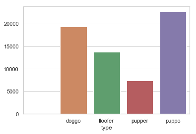

```python
sns.set(style="whitegrid")
sns.barplot(x=type.index, y=type.values)
```

##### the top 5 common dog names

```python
top_5 = combined_all.name.value_counts()[1:6]
top_5
```

```
Charlie    11
Cooper     10
Oliver     10
Lucy       10
Tucker      9
Name: name, dtype: int64
```

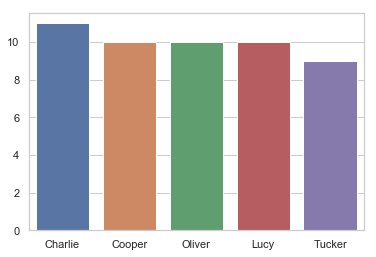

```python
sns.set(style='whitegrid')
sns.barplot(x=top_5.index, y=top_5.values)
```

##### comparsion of the correct rates against dog of p1, p2, p3

```python
combined_all.p1_dog.mean()
```

```
0.7404618473895582
```

```python
combined_all.p2_dog.mean()
```

```
0.7494979919678715
```

```python
combined_all.p3_dog.mean()
```

```
0.7248995983935743
```

*p1 has the highest confidence towards dog type, however, the correct rate of which is slightly lower than that of p2. Therefore the confidence towards dog type and correct rate dont have a strong relationship.*

##### presentation of the distribution of ratings

```python
ratings = combined_all.rating_numerator.value_counts()
ratings
```

```
12.0      454
10.0      422
11.0      402
13.0      261
9.0       151
8.0        95
7.0        51
14.0       36
5.0        33
6.0        32
3.0        19
4.0        15
2.0        10
1.0         4
0.0         2
27.0        1
1776.0      1
26.0        1
75.0        1
420.0       1
Name: rating_numerator, dtype: int64
```

```python
ratings = ratings.to_frame()
```

```python
ratings = ratings.reset_index().rename(columns={'index':'ratings', 'rating_numerator':'rating_count'})
```

```python
ratings
```

|  | ratings | rating_count |
| --- | --- | --- |
| 0 | 12.0 | 454 |
| 1 | 10.0 | 422 |
| 2 | 11.0 | 402 |
| 3 | 13.0 | 261 |
| 4 | 9.0 | 151 |
| 5 | 8.0 | 95 |
| 6 | 7.0 | 51 |
| 7 | 14.0 | 36 |
| 8 | 5.0 | 33 |
| 9 | 6.0 | 32 |
| 10 | 3.0 | 19 |
| 11 | 4.0 | 15 |
| 12 | 2.0 | 10 |
| 13 | 1.0 | 4 |
| 14 | 0.0 | 2 |
| 15 | 27.0 | 1 |
| 16 | 1776.0 | 1 |
| 17 | 26.0 | 1 |
| 18 | 75.0 | 1 |
| 19 | 420.0 | 1 |

```python
# check the abnormally high rating
combined_all[combined_all.rating_numerator==1776].text[979]
```

```
"This is Atticus. He's quite simply America af. 1776/10 https://t.co/GRXwMxLBkh"
```

```python
# check the abnormally high rating
combined_all[combined_all.rating_numerator==420].text[2074]
```

```
'After so many requests... here you go.\n\nGood dogg. 420/10 https://t.co/yfAAo1gdeY'
```

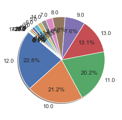

```python
labels = ratings.ratings
sizes = ratings.rating_count
plt.pie(sizes, labels=labels,autopct='%1.1f%%',pctdistance=0.7,shadow=True, startangle=140);
```

*drop the two highest ratings*

```python
drop_index = ratings[(ratings.ratings==1776) | (ratings.ratings==420)].index
ratings = ratings.drop(drop_index)
```

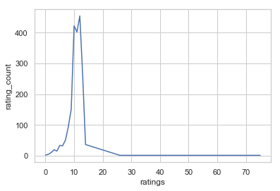

```python
sns.lineplot(x='ratings', y='rating_count', data=ratings)
```